# PCA mit anschließender Logistik Regression AIAV

Lars Mehnen

11/03/2022

Zuerst laden wir die notwendigen Bibliotheken, keras wird benötigt um das Datenset unkompliziert zur Verfügung zu stellen. nnet enthält eine Implementierung der Modelle die notwendig sind um Multinominelle Logistische Regression durchzuführen.

```r
rm(list=ls()) #Remove anythingfrom workspace
library(tensorflow)
library(keras)
library(nnet)
# theme_set(theme_bw())
```

Fallweise kann es notwendig sein, keras auch explizit zu installieren, dies kann über folgenden Befehl erfolgen.

```r
#install_keras()
```

Nun laden wir das “MNIST Fashion dataset” in die Variable “fashion_mnist”

```r
fashion_mnist <- keras::dataset_fashion_mnist()
```

```
## Loaded Tensorflow version 2.7.0
```

Anschließend werden die Daten auf test und training set aufgeteilt, sowie die dazugehörigen Kategorie-labels

```r
c(train.images, train.labels) %<-% fashion_mnist$train
c(test.images, test.labels) %<-% fashion_mnist$test
```

Wir überprüfen kurz die Daten, und sehen das hier ein Kleidungsstücke zu sehen sind

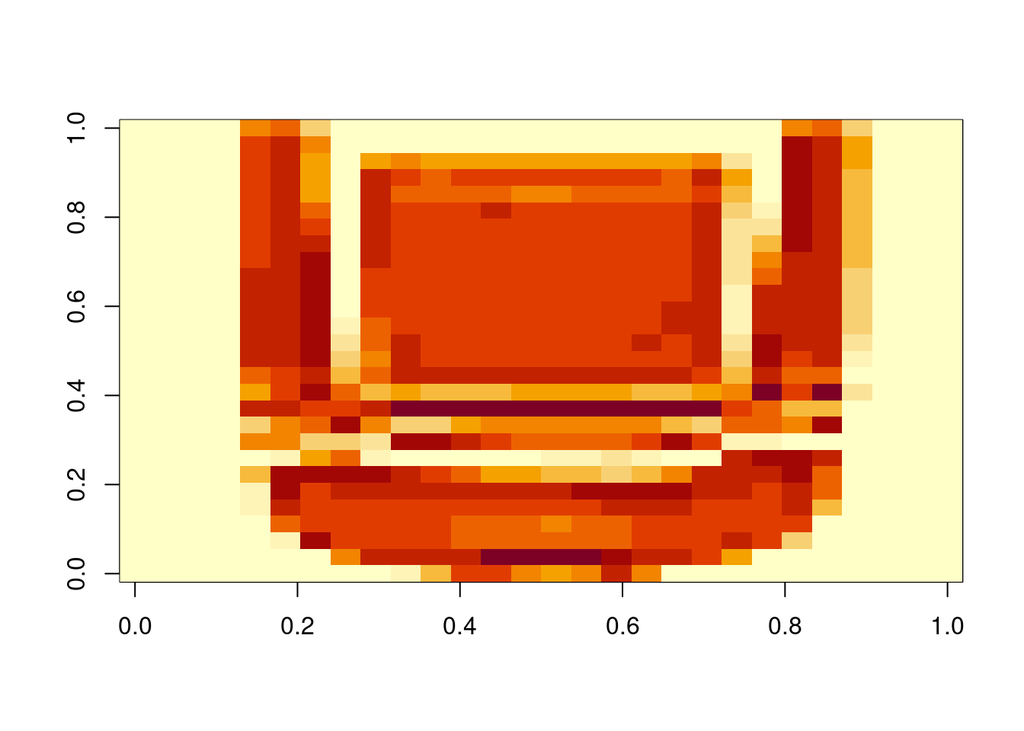

```r
image(t(train.images[6,,]))
```

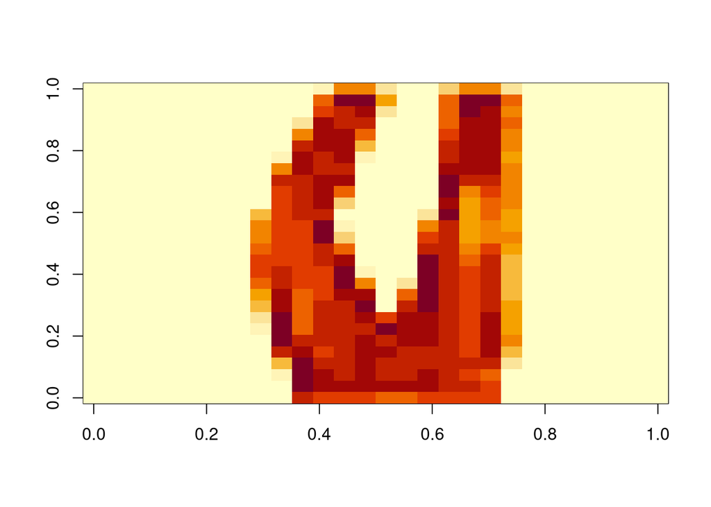

```r
image(t(test.images[6,,]))
```

Um die PCA zu erleichtern, wird die Dimension der Daten geändert. Die Pixel der Bilder werden zu einem Vektor, das heißt statt 28 Pixel (in X-Richtung) x 28 Pixel (in Y-Richtung) hat jedes Bild nun 1 x 784 Pixel.

```r
# change dimension of train images, as well as test images
dim(train.images) <- c(dim(train.images)[1], dim(train.images)[2]*dim(train.images)[3])
dim(test.images) <- c(dim(test.images)[1], dim(test.images)[2]*dim(test.images)[3])
```

Wir kommen zu der PCA, mit der wir die Dimensionalität verringern, und trainieren sie auf die Trainings-Daten

```r
pca <- prcomp(train.images, scale. = TRUE, center = TRUE, rank = 98)
```

```r
train.components <- predict(pca, newdata = train.images)
test.components  <- predict(pca, newdata = test.images)
```

Nun erstellen wir das Model, und übergeben hierbei unsere Labels für die Gewandstücke, sowie die Prinzipal Components. Multinomiale Logistic Regression # https://stats.oarc.ucla.edu/r/dae/multinomial-logistic-regression/

```r
model <- multinom(train.labels ~ ., family = "multinomial",
                  data = data.frame(train.components), maxit=10000);
```

[output not shown]

Nun nehmen wir die Test Daten und lassen das Modell versuchen, uns zu sagen welcher Kategorie die jeweiligen Daten zugehören.

```r
summary(model)
```

```
## Call:
## multinom(formula = train.labels ~ ., data = data.frame(train.components),
##     family = "multinomial", maxit = 10000)
##
## Coefficients:
##   (Intercept)          PC1         PC2        PC3        PC4        PC5
## 1  -8.7581713  0.084943455 -1.03160983  0.6277224  0.8430111 -1.1255372
## 2   0.2509515  0.031150985  0.01121936  0.3558845  0.2901205 -0.4818140
## 3  -3.2624041 -0.074670118 -0.53916526  0.2058370  0.3838568 -1.0204487
## 4  -1.8966403  0.043195610 -0.15101552  0.3800955  0.3323182 -1.1283130
## 5 -19.8902990 -1.748928682  1.26217327 -0.6113986 -0.5204182 -1.3751801
## 6   1.3011670  0.002874725  0.21387252  0.2167763  0.1428146 -0.2409160
## 7 -35.9805629 -2.726541090  0.77433604 -2.3925121  0.8033415 -3.3169250
## 8   1.0993823 -0.245238317  0.51450205 -0.1486481  0.1156615 -0.2884508
## 9 -26.7891091 -2.184991615  0.87428683 -2.2555512 -0.7532622 -1.3640406
```

[output cut: 315 more lines]

```r
results <- predict(model, newdata=test.components, type='probs')
```

Nun werden aus den prädiktierten Resultaten die Spalten ausgewählt, an denen die Wahrscheinlichkeit am höchsten ist. Dies wird als prädiktierte Kategorie angenommen.

```r
prediction <- max.col(results)
prediction <- prediction - 1
```

Zu guter letzt werden die Daten mit den Test-Labels verglichen, und gezählt wie oft die Daten übereinstimmen. Wenn die Klasse richtig ist, erhält sie den Wert 1, wenn sie falsch ist den Wert 0, dies wird über alle Fälle gemittelt und ergibt die Accuracy.

```r
cl <- mean(prediction == test.labels)
print(paste('Accuracy', cl))
```

```
## [1] "Accuracy 0.8374"
```